# 生物統計学レポート

髙良力樹

2024-07-22

## 0. データ構造

まずデータの中身をhead関数で見てみると

```
##      yield   variety year            site
## 1 27.00000 Manchuria 1931 University Farm
## 2 48.86667 Manchuria 1931          Waseca
## 3 27.43334 Manchuria 1931          Morris
## 4 39.93333 Manchuria 1931       Crookston
## 5 32.96667 Manchuria 1931    Grand Rapids
## 6 28.96667 Manchuria 1931          Duluth
```

variety・site・yearという3つの変数とそれに対応する変数yieldがある.

さらにデータ数自体に偏りがないかを確認すると各水準ごとに偏りはなく同じ数サンプリングされている.

```
## # A tibble: 6 × 2
##   variety       n
##   <fct>     <int>
## 1 Svansota     12
## 2 No. 462      12
## 3 Manchuria    12
## 4 No. 475      12
## 5 Velvet       12
## 6 Peatland     12
```

```
## # A tibble: 6 × 2
##   site                n
##   <fct>           <int>
## 1 Grand Rapids       20
## 2 Duluth             20
## 3 University Farm    20
## 4 Morris             20
## 5 Crookston          20
## 6 Waseca             20
```

```
## # A tibble: 2 × 2
##   year      n
##   <fct> <int>
## 1 1932     60
## 2 1931     60
```

## 1. オオムギ収量の箱ひげ図

一つ目の要因である品種をx軸にとった箱ひげ図をまず見てみる.

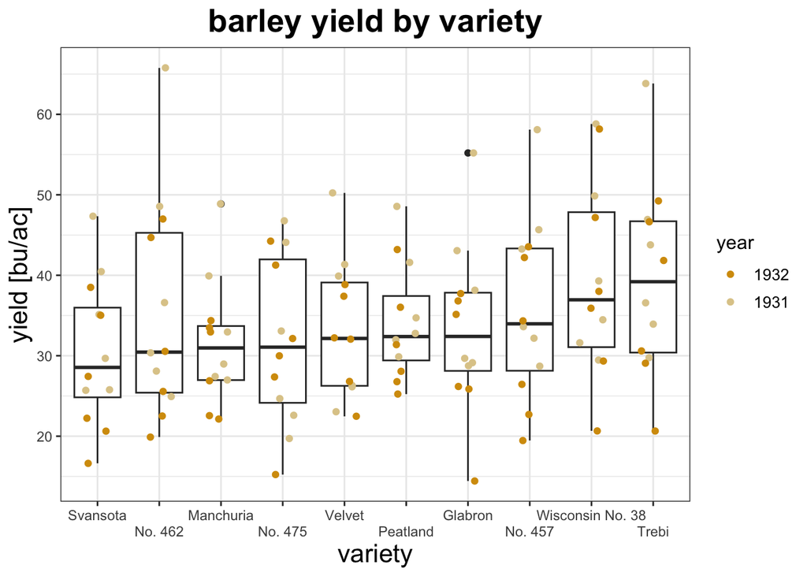

プロットは自動的に中央値（第二四分位数）が昇順で整列されて描画されているため、一見品種によって収量が変化しているように見える.

しかし実点を見てみると、最大点から最小点までかなり広い範囲でばらついている(つまり分散が大きい)データが多い. 例えばSvantosaとTrebiだとほとんどの点の描画範囲は変わらないが、Trebiは最大点が非常に大きいために中央値が引き上げられている可能性が高い.

次に2つ目の要因である、栽培地のデータを見てみる.

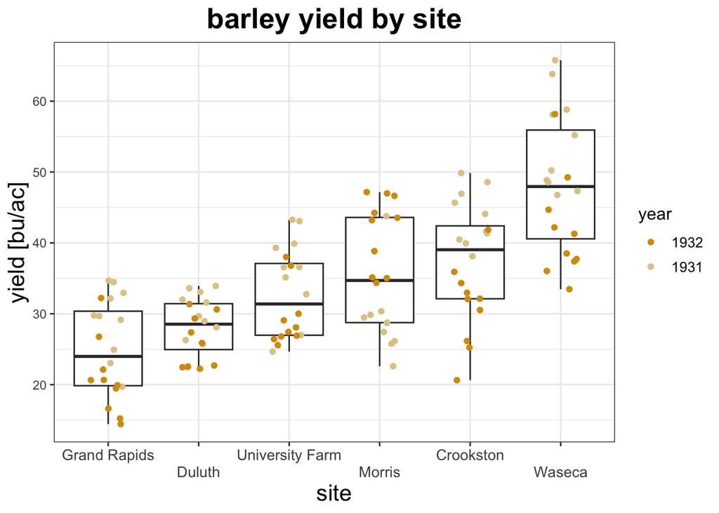

これをみると各サンプル集団の多くは狭い範囲に集中していて、中央値の差がはっきりあるように見える.

さらにもう一つの年度という変数に着目してみると、品種のグラフでは片方の年度だけ収量が高いといった偏りは特に見出せない. 一方で栽培地のグラフではばらけている栽培地と、Morrisのように年度で収量の平均が変動していそうに見えるサンプルもある.

これらのことから、オオムギの収量の変動要因は「**栽培地の影響が強く**」、「**品種の影響は栽培地による影響よりは弱そう**」であることがわかる. また植物の育成に大きく効く、環境の変動要因である「年度」は「年度と栽培地による偏り（交互作用）がありそうだがはっきりわからない」といったことがわかる.

## 2. 仮説の検定モデルと分散分析/補正

まずデータの形状から

- 栽培地が収量に影響する
- 品種の収量への影響は弱そう
- 品種と年度の関係性はなさそう
- 栽培地と年度には関係性がありそう

という事実が挙げられる.

この仮説の確からしさを示すために、「どの要素も収量に影響しない」という帰無仮説を立てる. 対立仮説としては「栽培地も品種も収量に影響し、年度は栽培地との交互作用がありそうだ」というモデルを採用する.

これらを踏まえてモデルを以下のように設定する.

```r
yield_nullmodel <- lm(yield ~ 1, data = barley)

yield_altmodel <- lm(yield ~ site + variety + 1 + site:year, data = barley)
```

上の回帰式は切片のみ（+誤差項）の栽培地と品種を考慮しないモデルで、下は栽培地による効果（ブロック効果）と品種（処理効果）という回帰係数を組み込み、また栽培地と年度による交互作用を考慮した上で収量が説明できると仮定したモデルである.

上記の各モデルに対して分散分析を行うと以下のようになる

```
## Analysis of Variance Table
##
## Response: yield
##            Df Sum Sq Mean Sq F value Pr(>F)
## Residuals 119  12710  106.81
```

```
## Anova Table (Type III tests)
##
## Response: yield
##             Sum Sq Df F value    Pr(>F)
## (Intercept) 1606.5  1 76.6852 5.587e-14 ***
## site        3593.8  5 34.3092 < 2.2e-16 ***
## variety     1052.6  9  5.5826 3.273e-06 ***
## site:year   2949.5  6 23.4653 < 2.2e-16 ***
## Residuals   2074.0 99
## ---
## Signif. codes:  0 '***' 0.001 '**' 0.01 '*' 0.05 '.' 0.1 ' ' 1
```

さらに水準間で多重比較を行っているため、Holm法による補正を行って各要素内の水準間で差があるかを比較する.

```
##
##  Pairwise comparisons using t tests with pooled SD
##
## data:  barley$yield and barley$variety
##
##                  Svansota No. 462 Manchuria No. 475 Velvet Peatland Glabron
## No. 462          1        -       -         -       -      -        -
## Manchuria        1        1       -         -       -      -        -
## No. 475          1        1       1         -       -      -        -
## Velvet           1        1       1         1       -      -        -
## Peatland         1        1       1         1       1      -        -
## Glabron          1        1       1         1       1      1        -
## No. 457          1        1       1         1       1      1        1
## Wisconsin No. 38 1        1       1         1       1      1        1
## Trebi            1        1       1         1       1      1        1
##                  No. 457 Wisconsin No. 38
## No. 462          -       -
## Manchuria        -       -
## No. 475          -       -
## Velvet           -       -
## Peatland         -       -
## Glabron          -       -
## No. 457          -       -
## Wisconsin No. 38 1       -
## Trebi            1       1
##
## P value adjustment method: holm
```

```
##
##  Pairwise comparisons using t tests with pooled SD
##
## data:  barley$yield and barley$site
##
##                 Grand Rapids Duluth  University Farm Morris  Crookston
## Duluth          0.56088      -       -               -       -
## University Farm 0.00766      0.20890 -               -       -
## Morris          0.00013      0.01045 0.56088         -       -
## Crookston       3.9e-06      0.00067 0.20890         0.56088 -
## Waseca          3.4e-16      3.8e-13 1.1e-08         2.8e-06 9.8e-05
##
## P value adjustment method: holm
```

```
##
##  Pairwise comparisons using t tests with pooled SD
##
## data:  barley$yield and barley$year
##
##      1932
## 1931 0.0044
##
## P value adjustment method: holm
```

## 3. 分散分析の結果の解釈と交互作用

### 3-1. 分散分析の結果の解釈

まずデータの形態から**収量には栽培地の影響が強く、それより弱いが品種の影響もある.さらに栽培地には年度による変動が影響する**という仮説を立てて検証した.

分散分析の結果からは全ての要因、つまり「栽培地」「品種」「栽培地と年度の交互作用」が全て $<0.1\%$ という水準のp値に達しており、この時点ではこれらの**要因が収量に影響しないという帰無仮説は棄却**できた.

### 3-2. 多重比較による結果の解釈

その上で各要因ごとに複数水準あるためHolm法で補正を行ったところ、まず品種ごとの平均収量の差は水準間での差がないという結果になった.

これを踏まえて各栽培地の年度ごとの収量平均をプロットしてみると、以下の図のようになる.

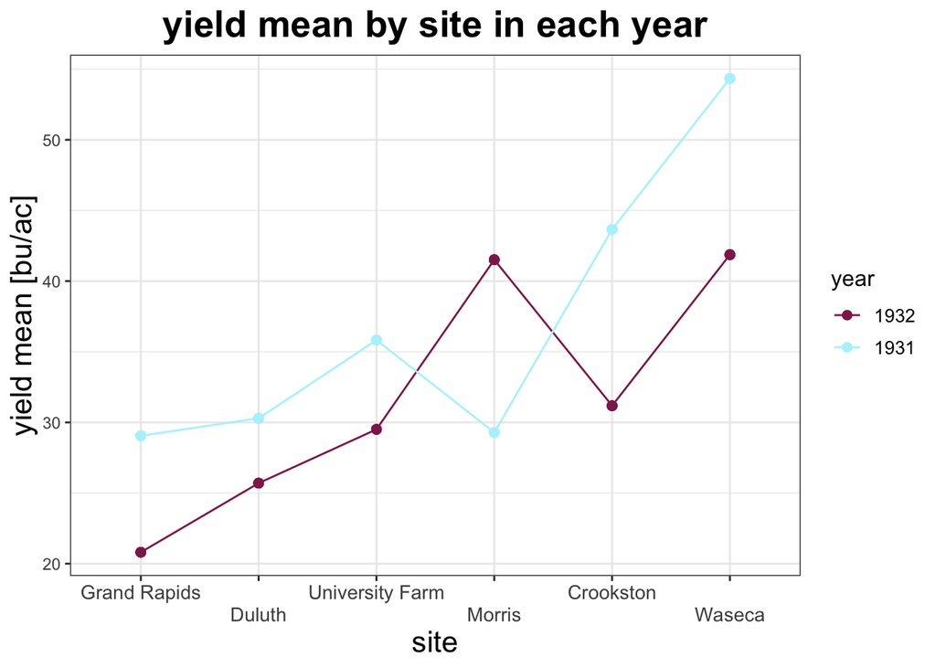

横軸に栽培地、縦軸に収量平均をとって年度で分けて折線グラフを描いている.

大枠として収量平均は右肩あがりに見えるため**栽培地によって収量平均が変化する**という事実が分かる. また年度でも全体的に1932年のものより1931年の方がほとんどの栽培地で収量平均の値が高いため年度による効果もありそうだと考えられる.

またグラフの傾きをみると、収量平均の変動率（栽培地点間の線の傾き）が異なっていたり、栽培地Morrisでは収量平均の変動が年度で逆転していたりする. このことは「当該栽培地の年度による環境の変動」、つまりは栽培地と年度による交互作用が収量平均に作用していると推測され、交互作用の可能性が考えられる.

これらのことから、少なくとも**このデータ内では栽培地と年度の交互作用で収量平均が変化する**という解釈が妥当と思われる.

交互作用について品種と年度についても見てみると

```r
variety_year_inter_model <- lm(yield ~ site + variety + 1 + variety:year, data = barley)
car::Anova(variety_year_inter_model , type="III")
```

```
## Anova Table (Type III tests)
##
## Response: yield
##              Sum Sq Df F value    Pr(>F)
## (Intercept)  1429.2  1 34.2312 6.929e-08 ***
## site         6633.9  5 31.7775 < 2.2e-16 ***
## variety       616.1  9  1.6395  0.115022
## variety:year 1057.1 10  2.5318  0.009487 **
## Residuals    3966.4 95
## ---
## Signif. codes:  0 '***' 0.001 '**' 0.01 '*' 0.05 '.' 0.1 ' ' 1
```

```r
all_inter_model <- lm(yield ~ site + variety + 1 + site:year + variety:year, data = barley)
car::Anova(all_inter_model , type="III")
```

```
## Anova Table (Type III tests)
##
## Response: yield
##              Sum Sq Df F value    Pr(>F)
## (Intercept)   997.4  1 48.1538 5.870e-10 ***
## site         3593.8  5 34.6999 < 2.2e-16 ***
## variety       616.1  9  3.3048  0.001589 **
## site:year    2260.6  6 18.1896 1.014e-13 ***
## variety:year  209.8  9  1.1253  0.353466
## Residuals    1864.2 90
## ---
## Signif. codes:  0 '***' 0.001 '**' 0.01 '*' 0.05 '.' 0.1 ' ' 1
```

品種と年度の交互作用のみがあると仮定したモデルでは交互作用項が有意水準になるが、栽培地と年度も加えたモデルだと有意水準に達しない.

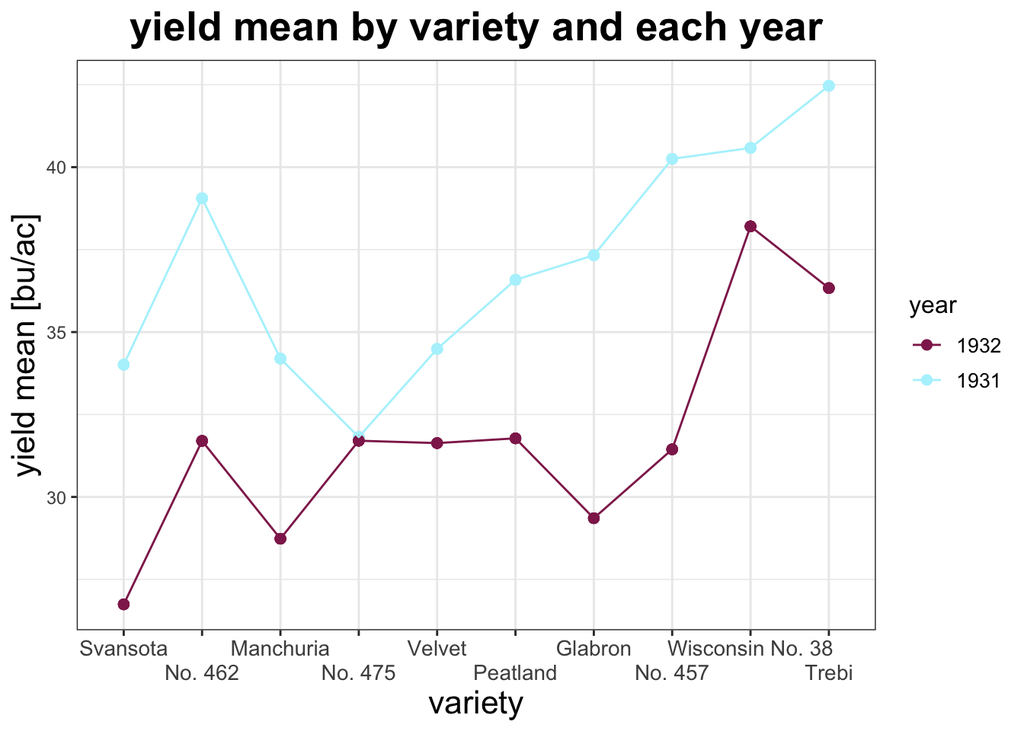